# P337: BAL and BE gene expression in response to allergen challenge

Relationships to eosinophils and FeNO

Kim Dill-McFarland, kadm@uw.edu

version March 08, 2023

# Background

The purpose of this workflow is to define the epithelial and cellular expression patterns that relate to eosinophil recruitment into the airway after allergen challenge.

These data were previously cleaned and modules were built from genes significant for allergen challenges. Briefly, low quality libraries were removed (median CV > 0.65, alignment < 80%, sequences < 1E6). Genes were filtered to protein-coding expressed at > 1 CPM in at least 10% of BAL and BE samples separately. TMM and voom log2 normalization was then completed. For details, see:

- BAL: https://github.com/altman-lab/P337_MINA_BAL_public
- BE: https://github.com/altman-lab/P337_MINA_BE_public

# Differentially expressed genes (DEG)

## Genes significant for allergen challenge (Post - Pre)

Post vs Pre allergen challenge

| FCgroup | sample | variable | fdr < 0.05 | fdr < 0.1 | fdr < 0.3 |
| --- | --- | --- | --- | --- | --- |
| down | BAL | visit | 1589 | 2169 | 3590 |
| up | BAL | visit | 1713 | 2128 | 3273 |
| down | BE | visit | 70 | 176 | 941 |
| up | BE | visit | 160 | 337 | 1135 |

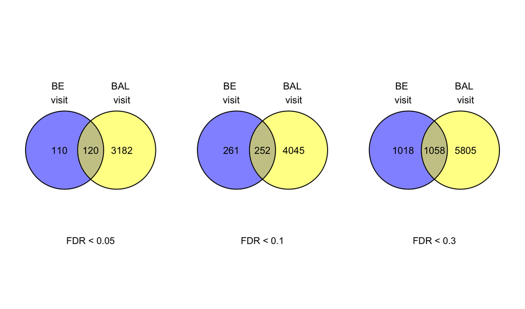

## Genes significant for allergen challenge and eosinophils

Data were filtered to genes significant for allergen challenge at FDR < 0.3. Samples were filtered to only Post allergen challenge as most Pre samples contained 0% eosinophils.

Eosinophil percent post allergen challenge

| FCgroup | sample | variable | fdr < 0.05 | fdr < 0.1 | fdr < 0.3 |
| --- | --- | --- | --- | --- | --- |
| down | BAL | EOS.pct | 684 | 933 | 1526 |
| up | BAL | EOS.pct | 1051 | 1324 | 2020 |
| down | BE | EOS.pct | 7 | 14 | 95 |
| up | BE | EOS.pct | 13 | 31 | 134 |

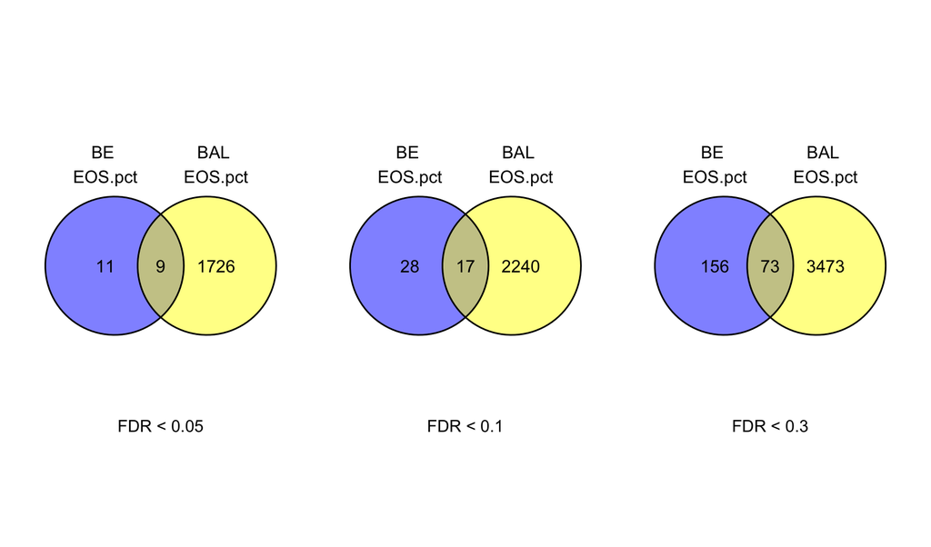

## Genes significant for allergen challenge and FeNO

As with eosinophil models, data were filtered to genes significant for allergen challenge (FDR < 0.3) and Post allergen challenge samples.

FeNO post allergen challenge

| FCgroup | sample | variable | fdr < 0.05 | fdr < 0.1 | fdr < 0.3 |
| --- | --- | --- | --- | --- | --- |
| up | BAL | FeNO | 1 | 75 | 930 |
| down | BAL | FeNO |  | 38 | 828 |
| down | BE | FeNO | 2 | 9 | 85 |
| up | BE | FeNO | 3 | 11 | 108 |

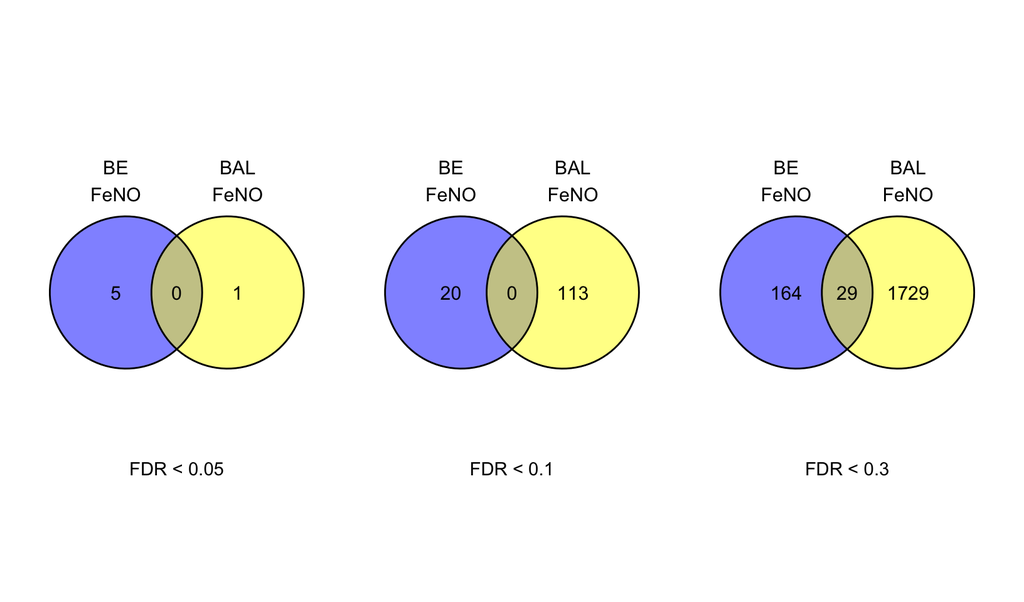

### DEG results files

See `DEG_lists.csv` for genes significant at FDR < 0.05, 0.1, and 0.3. Column names are `sample_variable_FDRcutoff`. Full model results can be found in `gene_lm_results.csv`

## DEG enrichment

### Summary

Total enriched pathways

| Sample | size_group | gs_cat | FDR < 0.01 | FDR < 0.1 |
| --- | --- | --- | --- | --- |
| **Visit DEG, FDR < 0.3** |  |  |  |  |
| BAL | 6863 | H | 6 | 13 |
|  | 6863 | C2 | 100 | 421 |
|  | 6863 | C5 | 313 | 953 |
| BE | 2076 | H | 4 | 7 |
|  | 2076 | C2 | 55 | 133 |
|  | 2076 | C5 | 99 | 238 |
| **EOS DEG, FDR < 0.1** |  |  |  |  |
| BAL | 2257 | H | 9 | 11 |
|  | 2257 | C2 | 33 | 206 |
|  | 2257 | C5 | 161 | 685 |
| BE | 45 | C2 |  | 3 |
|  | 45 | C5 |  | 6 |
| **FeNO DEG, FDR < 0.1** |  |  |  |  |
| BAL | 113 | H |  | 1 |
|  | 113 | C2 |  | 2 |
| BE | 20 | H |  | 2 |

### Eosinophils

Allergen challenge (FDR < 0.3) and eosinophil significant (FDR 0.1) gene sets. The following table includes up to the top 11 most significant (lowest FDR) gene sets in BAL and three databases (Hallmark, C2 canonical pathways, C5 GO biological processes). This includes all BE significant gene sets as well as all BAL H significant gene sets. BAL C2 and C5 lists are reduced by the top 11 cutoff.

Eosinophil enriched pathways

| Sample | gs_cat | pathway | FDR |
| --- | --- | --- | --- |
| BAL | H | HALLMARK_IL2_STAT5_SIGNALING | 3.0e-07 |
|  |  | HALLMARK_INFLAMMATORY_RESPONSE | 3.9e-05 |
|  |  | HALLMARK_ESTROGEN_RESPONSE_EARLY | 1.1e-04 |
|  |  | HALLMARK_INTERFERON_GAMMA_RESPONSE | 1.4e-03 |
|  |  | HALLMARK_TNFA_SIGNALING_VIA_NFKB | 1.4e-03 |
|  |  | HALLMARK_KRAS_SIGNALING_UP | 1.7e-03 |
|  |  | HALLMARK_P53_PATHWAY | 5.4e-03 |
|  |  | HALLMARK_IL6_JAK_STAT3_SIGNALING | 8.6e-03 |
|  |  | HALLMARK_INTERFERON_ALPHA_RESPONSE | 8.6e-03 |
|  |  | HALLMARK_APOPTOSIS | 7.1e-02 |
|  |  | HALLMARK_TGF_BETA_SIGNALING | 9.2e-02 |
|  | C2 | WP_TYROBP_CAUSAL_NETWORK_IN_MICROGLIA | 2.6e-05 |
|  |  | REACTOME_RHO_GTPASE_CYCLE | 2.6e-05 |
|  |  | REACTOME_RAC1_GTPASE_CYCLE | 1.9e-04 |
|  |  | KEGG_ACUTE_MYELOID_LEUKEMIA | 1.9e-04 |
|  |  | KEGG_CYTOKINE_CYTOKINE_RECEPTOR_INTERACTION | 3.2e-04 |
|  |  | WP_HEMATOPOIETIC_STEM_CELL_DIFFERENTIATION | 3.2e-04 |
|  |  | KEGG_HEMATOPOIETIC_CELL_LINEAGE | 3.6e-04 |
|  |  | REACTOME_FATTY_ACID_METABOLISM | 7.7e-04 |
|  |  | WP_CHEMOKINE_SIGNALING_PATHWAY | 7.9e-04 |
|  |  | REACTOME_CDC42_GTPASE_CYCLE | 9.0e-04 |
|  |  | REACTOME_INTERLEUKIN_2_FAMILY_SIGNALING | 1.7e-03 |
|  |  | REACTOME_INTERLEUKIN_4_AND_INTERLEUKIN_13_SIGNALING | 1.7e-03 |
|  | C5 | GOBP_LEUKOCYTE_MIGRATION | 0.0e+00 |
|  |  | GOBP_REGULATION_OF_INFLAMMATORY_RESPONSE | 0.0e+00 |
|  |  | GOBP_CELL_CHEMOTAXIS | 0.0e+00 |
|  |  | GOBP_MYELOID_LEUKOCYTE_ACTIVATION | 0.0e+00 |
|  |  | GOBP_LEUKOCYTE_CHEMOTAXIS | 0.0e+00 |
|  |  | GOBP_REGULATION_OF_SMALL_GTPASE_MEDIATED_SIGNAL_TRANSDUCTION | 1.0e-07 |
|  |  | GOBP_T_CELL_DIFFERENTIATION | 7.0e-07 |
|  |  | GOBP_MONONUCLEAR_CELL_MIGRATION | 1.0e-06 |
|  |  | GOBP_REGULATION_OF_HEMOPOIESIS | 1.0e-06 |
|  |  | GOBP_MYELOID_CELL_DIFFERENTIATION | 1.0e-06 |
|  |  | GOBP_ACTIN_FILAMENT_ORGANIZATION | 1.4e-06 |
| BE | C2 | REACTOME_CHEMOKINE_RECEPTORS_BIND_CHEMOKINES | 6.6e-02 |
|  |  | REACTOME_COMMON_PATHWAY_OF_FIBRIN_CLOT_FORMATION | 7.3e-02 |
|  |  | WP_METHIONINE_DE_NOVO_AND_SALVAGE_PATHWAY | 7.3e-02 |
|  | C5 | GOBP_RESPONSE_TO_CHEMOKINE | 2.4e-02 |
|  |  | GOBP_CALCIUM_MEDIATED_SIGNALING | 2.4e-02 |
|  |  | GOBP_NEGATIVE_REGULATION_OF_COAGULATION | 3.4e-02 |
|  |  | GOBP_REGULATION_OF_COAGULATION | 5.9e-02 |
|  |  | GOBP_SECOND_MESSENGER_MEDIATED_SIGNALING | 5.9e-02 |
|  |  | GOBP_AMINO_ACID_BETAINE_METABOLIC_PROCESS | 6.3e-02 |

C5 GO terms in BAL are further explored based on GO hierarchy since there are so many. Here, we use the gene sets at FDR < 0.01 and group similar terms under their parent terms (similarity > 0.7).

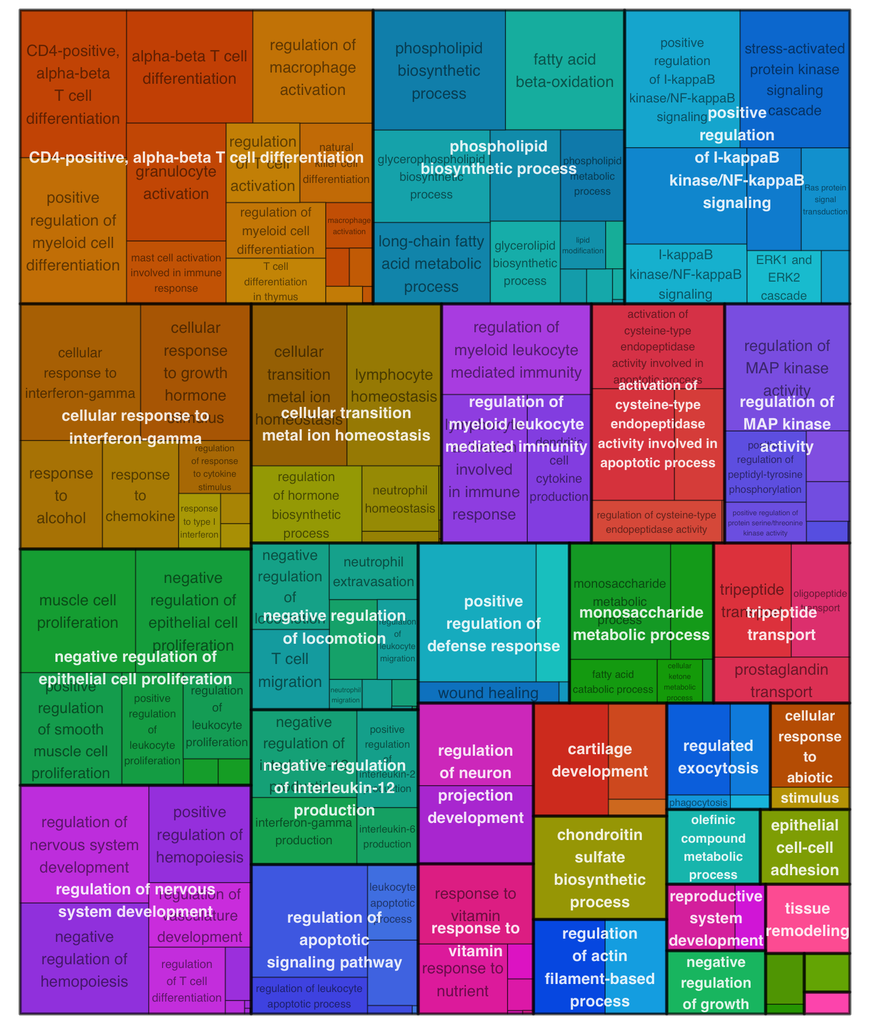

### FeNO

Allergen challenge (FDR < 0.3) and FeNO significant (FDR 0.1) gene sets. The following table includes all significant gene sets in BAL and BE.

FeNO enriched pathways

| Sample | gs_cat | pathway | FDR |
| --- | --- | --- | --- |
| BAL | H | HALLMARK_NOTCH_SIGNALING | 0.039 |
|  | C2 | KEGG_PHOSPHATIDYLINOSITOL_SIGNALING_SYSTEM | 0.054 |
|  |  | REACTOME_SIGNALING_BY_ALK_IN_CANCER | 0.093 |
| BE | H | HALLMARK_HEDGEHOG_SIGNALING | 0.041 |
|  |  | HALLMARK_TNFA_SIGNALING_VIA_NFKB | 0.083 |

# Comparing gene expression in BAL and BE

## Eosinophils

Allergen challenge (FDR < 0.3) and eosinophil significant (FDR 0.1) genes in BAL vs BE. As expected, genes can be grouped into those that positively associate with eosinophils in both BAL and BE (positive correlation) and those that have opposite directionality in BAL and BE (negative correlation).

#### Genes positively associated with eosinophils

There is additional notation if the gene was also significant for FeNO but this figure does not contain all FeNo significant genes.

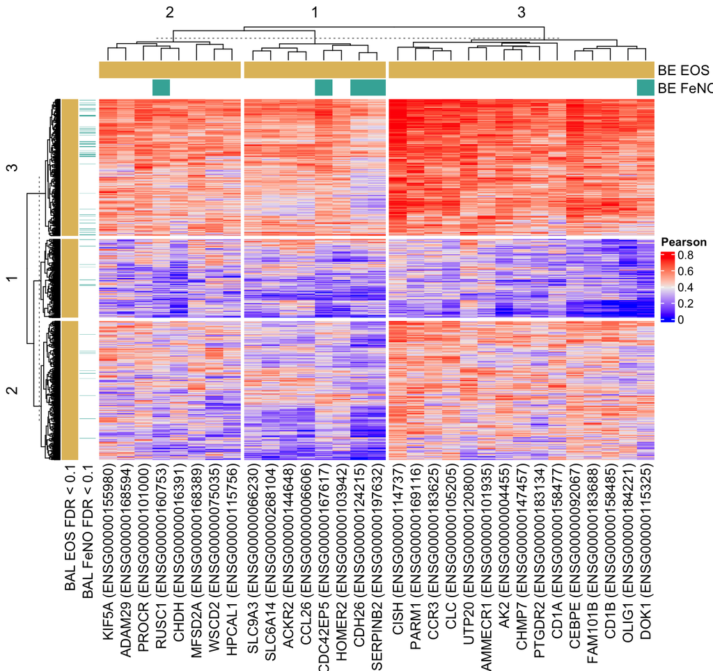

#### Genes negatively associated with eosinophils

There is additional notation if the gene was also significant for FeNO but this figure does not contain all FeNo significant genes.

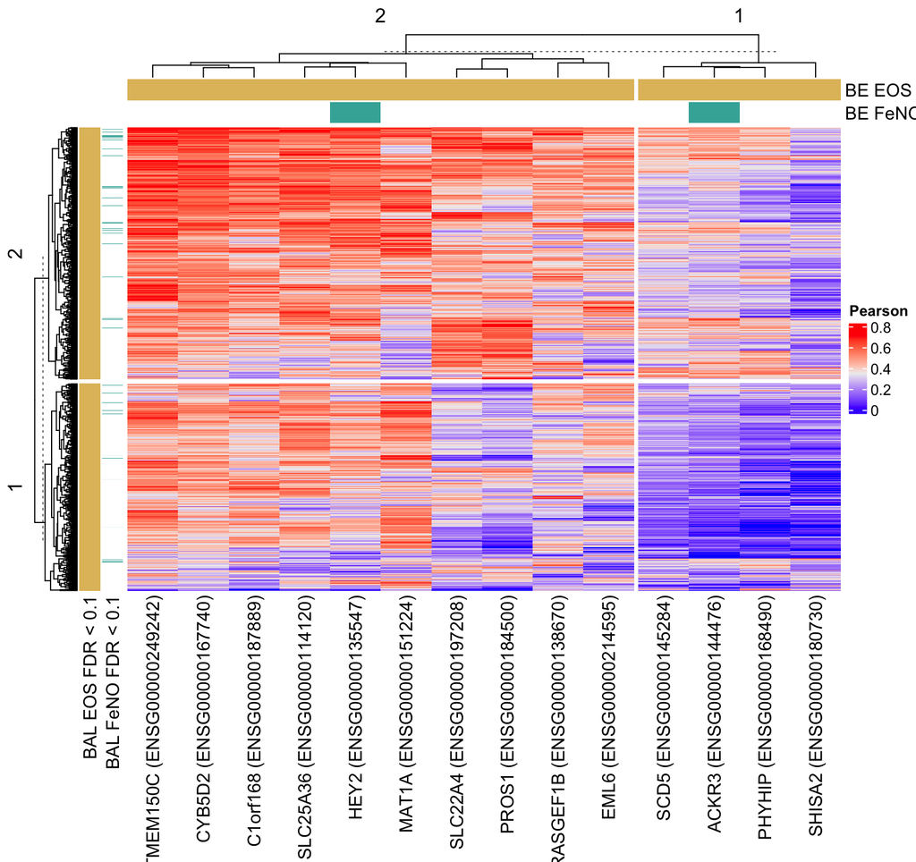

## FeNO

Allergen challenge (FDR < 0.3) and FeNO significant (FDR 0.1) genes in BAL vs BE. As expected, genes can be grouped into those that positively associate with FeNO in both BAL and BE (positive correlation) and those that have opposite directionality in BAL and BE (negative correlation).

#### Genes positively associated with FeNO

There is additional notation if the gene was also significant for eosinophils but this figure does not contain all eosinophil significant genes.

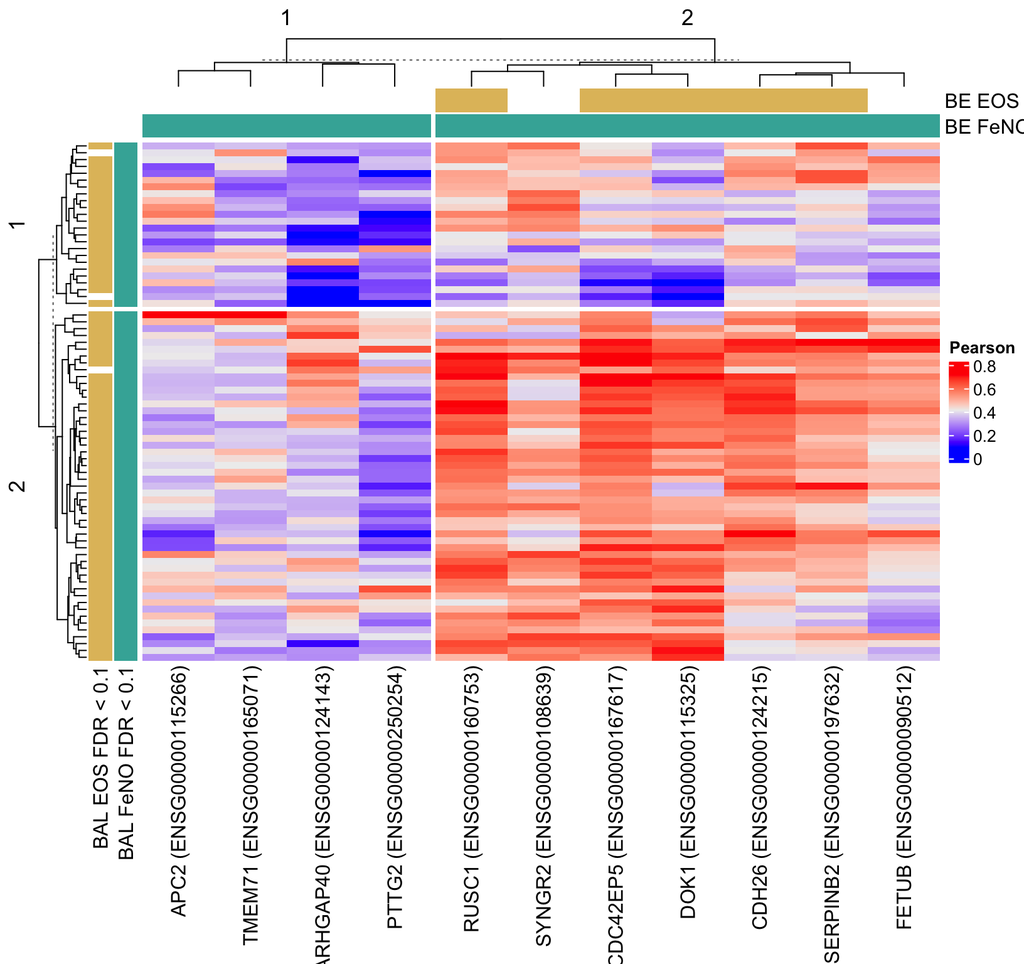

#### Genes negatively associated with FeNO

There is additional notation if the gene was also significant for eosinophils but this figure does not contain all eosinophil significant genes.

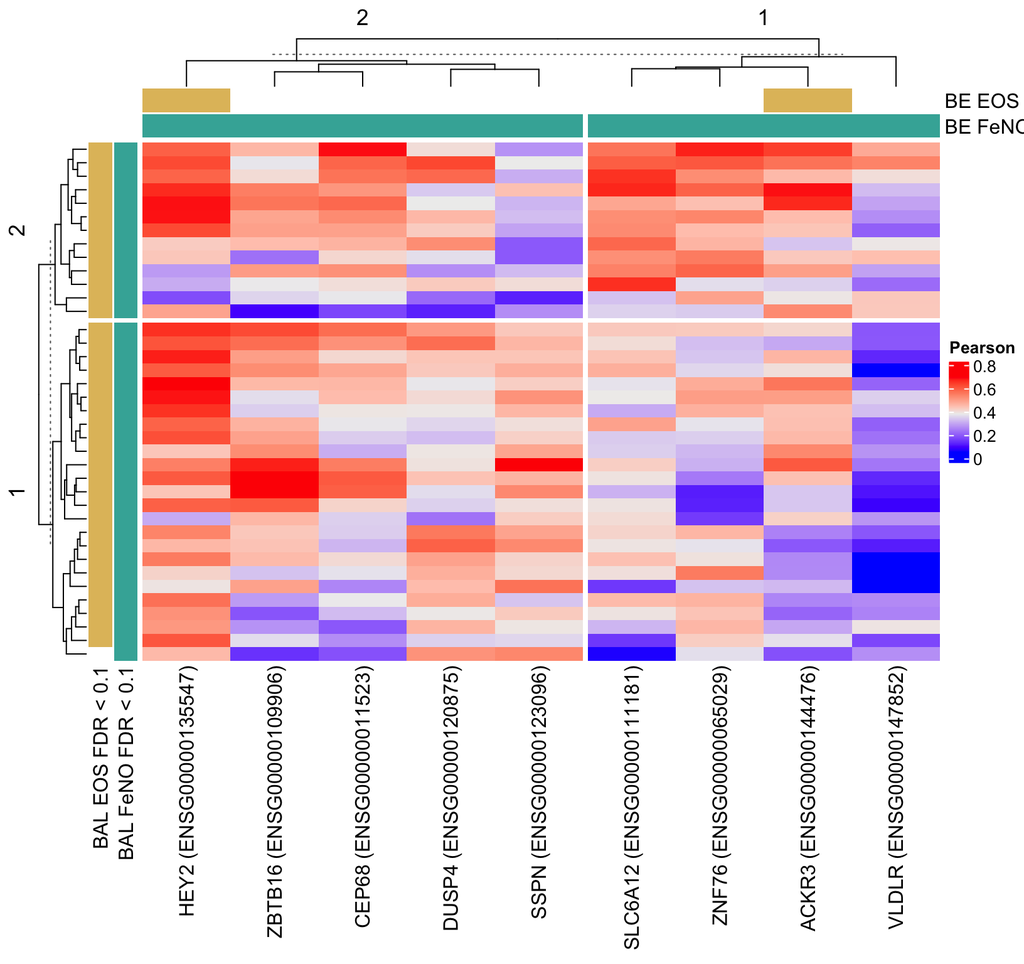

# Gene plots

All genes significant for eosinophils and/or FeNO can be found in the zipped folder `figs/DEG/`